# PRUEBA DE GERMINACION EN QUINOA

Author

Grupo 6

# 1 INTRODUCCIÓN

La germinación es el proceso mediante el cual las semillas comienzan a desarrollarse, y está influenciada por diversos factores, entre los que se incluyen la luz y la oscuridad. La quinua (*Chenopodium quinoa*), una planta andina reconocida por su alto valor nutricional, presenta un interés particular en cuanto a su respuesta a la luz durante la germinación, un aspecto que aún requiere más estudio. Las condiciones ambientales, como la presencia de luz, pueden afectar de manera significativa este proceso, y es crucial investigar cómo influye en la germinación de la quinua para optimizar su cultivo y productividad.

# 2 OBJETIVO

Evaluar el efecto de la luz en la germinación, la media de germinación y la sincronía de germinación de las semillas, comparando los tratamientos con luz y sin luz.

# 3 MATERIALES Y MÉTODOS

## 3.1 Muestreo y condiciones experimentales

- Se utilizaron 12 táperes desechables de un kilo con tapa. Estos fueron distribuidos en dos grupos:
- 6 táperes fueron expuestos a condiciones de luz natural.
- 6 táperes fueron cubiertos con papel aluminio para generar condiciones de oscuridad.

En cada táper se colocaron 50 semillas de quinua.

## 3.2 Descripción de los materiales utilizados

- Táperes: 12 de un kilo con tapa.
- Papel aluminio: Utilizado para cubrir los táperes que se mantenían en oscuridad.
- Agua destilada: Para el riego de las semillas.
- Pinza: Para colocar las semillas y evitar contaminación.
- Papel toalla: para mantener la humedad en el interior de los táperes.
- Tijeras: Para cortar el papel aluminio utilizado para crear la oscuridad.
- Semillas de quinua: Se usaron 50 semillas por táper.

# 4 RESULTADOS

**Grafica 1: Numero de Semilla Germinación**

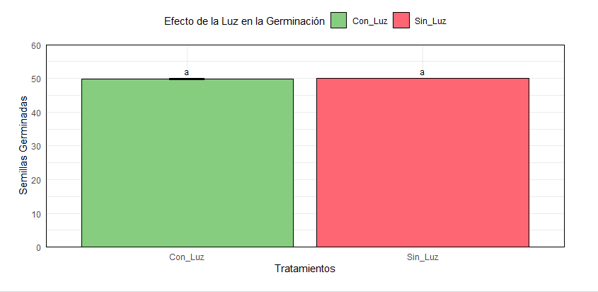

Nota: Los tratamientos no muestran diferencias significativas.

**Grafica 2: Efecto de la luz en el porcentaje de germinación**

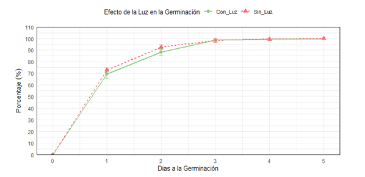

Notas: Los tratamientos muestran una germinación similar a lo largo de los días.

**Grafica 3: Tiempo de germinación**

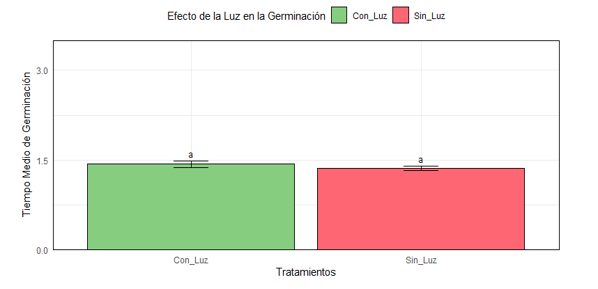

El tiempo medio de germinación es similar entre los tratamientos.

**Grafica 4: Sincronización de la semilla**

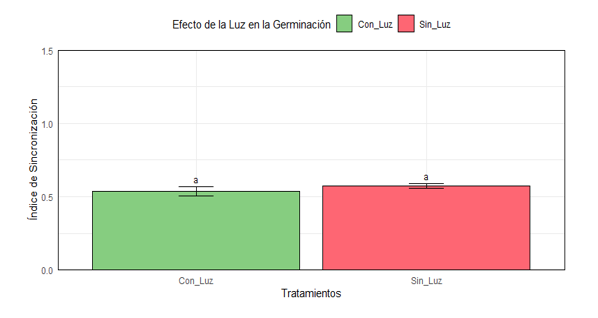

El índice de sincronía es similar entre los tratamientos.

# 5 DISCUSIÓN

- Se observaron germinaciones en ambos grupos desde el primer día, con la mayoría de las semillas germinando (más de 30) en ambos grupos (luz y oscuridad).
- No se encontró una diferencia significativa en la tasa de germinación entre las condiciones de luz y oscuridad, lo que sugiere que la luz no es un factor determinante en este caso para la germinación de las semillas de quinua.

**Herramientas utilizadas para el análisis de datos**

- Hojas de cálculo de Google: Para organizar y almacenar los datos de germinación.
- R Studio y GerminaQuant: Para procesar los datos y generar gráficos que permitieran visualizar la evolución de la germinación.

# 6 CONCLUSIONES

- No se observó diferencia significativa en la germinación entre los tratamientos “Con Luz” y “Sin Luz”, ya que ambos presentaron porcentajes de germinación similares a lo largo del tiempo.
- El tiempo medio de germinación fue comparable entre ambos tratamientos, indicando que la luz no tuvo un efecto considerable en la rapidez de la germinación de las semillas.
- El índice de sincronización de la germinación también fue similar en ambos tratamientos, lo que sugiere que la luz no influyó en la uniformidad del proceso de germinación entre las semillas.
- El uso de herramientas estadísticas como R Studio y GerminaQuant permitió una organización y análisis adecuados de los datos, generando gráficos que facilitaron la visualización de los resultados.

# 7 REFERENCIAS

- Suárez, D., & Melgarejo, L. M. (2010). Biología y germinación de semillas. Experimentos en fisiología vegetal, 13-25.